# In Course Exercise 4

Brooke Anderson

January 12, 2016

```r
library(knitr)
library(dplyr)
library(tidyr)
library(ggplot2)
library(gridExtra)
library(ggthemes)
```

## Easier data wrangling

- Read in the data files “mexico_deaths.csv” and “mexico_exposure.csv” from the directory called `data`. Call the dataframes `mex_deaths` and `mex_exp`.
- Merge the two datasets together to create the dataframe `mexico`. Exclude all columns except the outcome (deaths), date, and mean temperature. Convert the date to a date class.
- Try combining all the steps in the previous task into one “chained” command.
- Use this new dataframe to plot deaths by date using `ggplot`.

### Example R code

Read in the two datasets. Call the dataframes `mex_deaths` and `mex_exp`:

```r
mex_deaths <- read.csv("data/mexico_deaths.csv", header = TRUE)
head(mex_deaths)
```

```
##      day deaths
## 1 1/1/08    296
## 2 1/2/08    274
## 3 1/3/08    339
## 4 1/4/08    300
## 5 1/5/08    327
## 6 1/6/08    332
```

```r
mex_exp <- read.csv("data/mexico_exposure.csv", header = TRUE)
head(mex_exp)
```

```
##      day temp_min temp_max temp_mean humidity      wind          NO
## 1 1/1/08      7.8     17.8 11.770833 53.45833 2.6625000 0.009250000
## 2 1/2/08      2.6      9.8  6.637500 61.70833 3.3458333 0.005416667
## 3 1/3/08      1.1     15.6  7.041667 59.91667 1.8857143 0.015958333
## 4 1/4/08      3.1     20.6 10.862500 57.54167 1.1958333 0.040833333
## 5 1/5/08      6.0     21.3 13.404167 45.70833 0.9875000 0.046916667
## 6 1/6/08      7.2     22.1 14.341667 40.75000 0.8541667 0.028583333
##          NO2        NOX         O3        CO         SO2      PM10
## 1 0.01870833 0.02783333         NA        NA 0.004875000  92.50000
## 2 0.01870833 0.02408333 0.02008333 0.7291667 0.000041700        NA
## 3 0.03808333 0.05395833 0.01841667 1.4083333 0.008958333        NA
## 4 0.05837500 0.09929167 0.02150000 1.8833333 0.021166667  93.66667
## 5 0.06016667 0.10712500 0.02387500 3.3625000 0.020791667 108.25000
## 6 0.05100000 0.07945833 0.02491667 2.8791667 0.011291667  84.58333
##        PM25
## 1  92.50000
## 2        NA
## 3        NA
## 4  93.66667
## 5 108.25000
## 6  84.58333
```

Merge the two datasets together to create the dataframe `mexico`. Exclude all columns except the outcome (deaths), date, and mean temperature. Convert the date to a date class.

```r
mexico <- full_join(mex_deaths, mex_exp, by = "day")
mexico <- select(mexico, day, deaths, temp_mean)
mexico <- mutate(mexico, day = as.Date(day, format = "%m/%d/%y"))
```

Try combining all the steps in the previous task into one “chained” command:

```r
mexico <- full_join(mex_deaths, mex_exp, by = "day") %>%
        select(day, deaths, temp_mean) %>%
        mutate(day = as.Date(day, format = "%m/%d/%y"))
```

Use this new dataframe to plot deaths by date using `ggplot`:

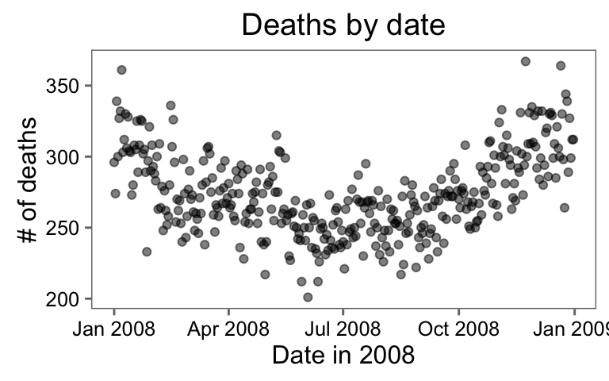

```r
ggplot(mexico, aes(x = day, y = deaths)) +
        geom_point(size = 1.5, alpha = 0.5) +
        xlab("Date in 2008") + ylab("# of deaths") +
        ggtitle("Deaths by date") +
        theme_few()
```

## More extensive data wrangling

- Read in the ebola data from the file “country_timeseries.csv” in the `data` directory into your R session. Call the dataframe `ebola`.
- Use `dplyr` functions to create a tidy dataset. First, change it from “wide” data to “long” data. Name the new column with the key `variable` and the new column with the values `count`.
- Run the following code to create new columns named `type` and `country` that split up the `variable` column into type (“Cases” or “Deaths”) and country (“Guinea”, “Liberia”, etc.). (This type of code is moving towards using regular expressions to clean up really messy data, which we’ll talk about some in the third section.)

```r
foo <- strsplit(as.character(ebola$variable), split = "_")
bar <- matrix(unlist(foo), ncol = 2, byrow = TRUE)

ebola$type <- factor(bar[ , 1])
ebola$country <- factor(bar[ , 2])
```

- Use `dplyr` functions and piping to remove `Day` and `variable` (now that you’ve split it into `type` and `country`) and to convert `Date` to a date class.
- Use the `dplyr` function `spread()` to convert the data so you have separate columns for the two variables of numbers of `Cases` and `Deaths`.
- Remove any observations where counts of cases or deaths are missing for that country.
- Challenge question (you can do the next step without doing this, but your graphs won’t be in order): Create a dataframe called `case_sum` that gives the total number of cases recorded for each country. (Hint: Use the `dplyr` functions `group_by()` and `summarize()`.) Use `arrange()` to re-order this dataset by the order of the number of cases, and then use this arrangement to re-order the levels in `country` in your main `ebola` dataset, so that your graphs in the next step will be ordered from the country with the most ebola cases to the one with the least.
- Now that your data is tidy, create one plot showing ebola cases by date, faceted by country, and one showing ebola deaths by date, also faceted by country. Try using the option `scales = "free_y"` in the `facet_wrap()` function (in the `gridExtra` package) and see how that changes these graphs.
- Based on these plots, what would your next questions be about this data before you used it for an analysis?
- Super-challenge question: Can you put all of the steps of this cleaning process into just a few “chaining” calls?

### Example R code

Read the data in using `read.csv()`.

```r
ebola <- read.csv("data/country_timeseries.csv", header = TRUE)
head(ebola)
```

```
##         Date Day Cases_Guinea Cases_Liberia Cases_SierraLeone
## 1   1/5/2015 289         2776            NA             10030
## 2   1/4/2015 288         2775            NA              9780
## 3   1/3/2015 287         2769          8166              9722
## 4   1/2/2015 286           NA          8157                NA
## 5 12/31/2014 284         2730          8115              9633
## 6 12/28/2014 281         2706          8018              9446
##   Cases_Nigeria Cases_Senegal Cases_UnitedStates Cases_Spain Cases_Mali
## 1            NA            NA                 NA          NA         NA
## 2            NA            NA                 NA          NA         NA
## 3            NA            NA                 NA          NA         NA
## 4            NA            NA                 NA          NA         NA
## 5            NA            NA                 NA          NA         NA
## 6            NA            NA                 NA          NA         NA
##   Deaths_Guinea Deaths_Liberia Deaths_SierraLeone Deaths_Nigeria
## 1          1786             NA               2977             NA
## 2          1781             NA               2943             NA
## 3          1767           3496               2915             NA
## 4            NA           3496                 NA             NA
## 5          1739           3471               2827             NA
## 6          1708           3423               2758             NA
##   Deaths_Senegal Deaths_UnitedStates Deaths_Spain Deaths_Mali
## 1             NA                  NA           NA          NA
## 2             NA                  NA           NA          NA
## 3             NA                  NA           NA          NA
## 4             NA                  NA           NA          NA
## 5             NA                  NA           NA          NA
## 6             NA                  NA           NA          NA
```

Change the data to long data using the `gather()` function from `tidyr`:

```r
ebola <- gather(ebola, variable, count, -Date, -Day)
head(ebola)
```

```
##         Date Day     variable count
## 1   1/5/2015 289 Cases_Guinea  2776
## 2   1/4/2015 288 Cases_Guinea  2775
## 3   1/3/2015 287 Cases_Guinea  2769
## 4   1/2/2015 286 Cases_Guinea    NA
## 5 12/31/2014 284 Cases_Guinea  2730
## 6 12/28/2014 281 Cases_Guinea  2706
```

Split `variable` into `type` and `country`:

```r
foo <- strsplit(as.character(ebola$variable), split = "_")
ebola[ , c("type", "country")] <- matrix(unlist(foo), ncol = 2, byrow = TRUE)

head(ebola)
```

```
##         Date Day     variable count  type country
## 1   1/5/2015 289 Cases_Guinea  2776 Cases  Guinea
## 2   1/4/2015 288 Cases_Guinea  2775 Cases  Guinea
## 3   1/3/2015 287 Cases_Guinea  2769 Cases  Guinea
## 4   1/2/2015 286 Cases_Guinea    NA Cases  Guinea
## 5 12/31/2014 284 Cases_Guinea  2730 Cases  Guinea
## 6 12/28/2014 281 Cases_Guinea  2706 Cases  Guinea
```

Use `dplyr` functions and piping to remove `Day` and `variable` and to convert `Date` to a date class:

```r
ebola <- select(ebola, -Day, -variable) %>%
        mutate(Date = as.Date(Date, format = "%m/%d/%Y"))
head(ebola)
```

```
##         Date count  type country
## 1 2015-01-05  2776 Cases  Guinea
## 2 2015-01-04  2775 Cases  Guinea
## 3 2015-01-03  2769 Cases  Guinea
## 4 2015-01-02    NA Cases  Guinea
## 5 2014-12-31  2730 Cases  Guinea
## 6 2014-12-28  2706 Cases  Guinea
```

Convert the data so you have separate columns for the two variables of numbers of `Cases` and `Deaths`:

```r
ebola <- spread(ebola, type, count)
head(ebola)
```

```
##         Date     country Cases Deaths
## 1 2014-03-22      Guinea    49     29
## 2 2014-03-22     Liberia    NA     NA
## 3 2014-03-22        Mali    NA     NA
## 4 2014-03-22     Nigeria    NA     NA
## 5 2014-03-22     Senegal    NA     NA
## 6 2014-03-22 SierraLeone    NA     NA
```

Remove any observations where counts of cases or deaths are missing for that country:

```r
ebola <- filter(ebola, !is.na(Cases) & !is.na(Deaths))
head(ebola)
```

```
##         Date country Cases Deaths
## 1 2014-03-22  Guinea    49     29
## 2 2014-03-24  Guinea    86     59
## 3 2014-03-25  Guinea    86     60
## 4 2014-03-26  Guinea    86     62
## 5 2014-03-27  Guinea   103     66
## 6 2014-03-27 Liberia     8      6
```

Create a dataframe called `case_sum` that gives the total number of cases recorded for each country. Use `arrange()` to re-order this dataset by the order of the number of cases:

```r
case_sum <- group_by(ebola, country) %>%
        summarize(Cases = sum(Cases, na.rm = TRUE))
case_sum
```

```
## Source: local data frame [8 x 2]
##
##        country  Cases
##          (chr)  (int)
## 1       Guinea  82099
## 2      Liberia 191351
## 3         Mali     42
## 4      Nigeria    636
## 5      Senegal     24
## 6  SierraLeone 211169
## 7        Spain     16
## 8 UnitedStates     59
```

Use this arrangement to re-order the levels in `country` in your main `ebola` dataset, so that your graphs in the next step will be ordered from the country with the most ebola cases to the one with the least:

```r
case_sum <- arrange(case_sum, desc(Cases))
case_sum
```

```
## Source: local data frame [8 x 2]
##
##        country  Cases
##          (chr)  (int)
## 1  SierraLeone 211169
## 2      Liberia 191351
## 3       Guinea  82099
## 4      Nigeria    636
## 5 UnitedStates     59
## 6         Mali     42
## 7      Senegal     24
## 8        Spain     16
```

```r
levels(ebola$country)
```

[output not shown]

```r
ebola <- mutate(ebola,
                country = factor(country, levels = case_sum$country))
levels(ebola$country)
```

```
## [1] "SierraLeone"  "Liberia"      "Guinea"       "Nigeria"
## [5] "UnitedStates" "Mali"         "Senegal"      "Spain"
```

Now that your data is tidy, create one plot showing ebola cases by date, faceted by country, and one showing ebola deaths by date, also faceted by country:

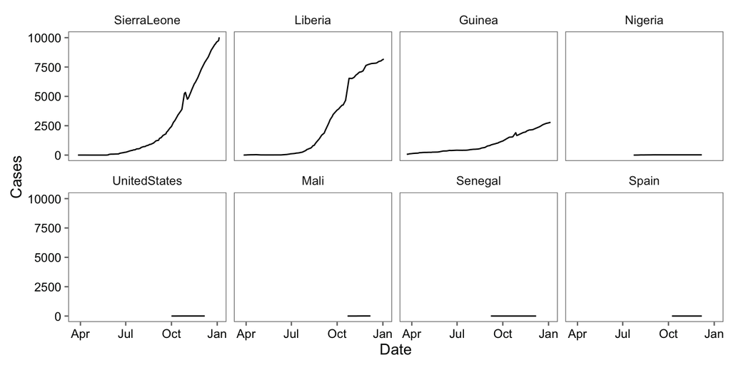

```r
ggplot(ebola, aes(x = Date, y = Cases)) +
        geom_line() +
        facet_wrap(~ country, ncol = 4) +
        theme_few()
```

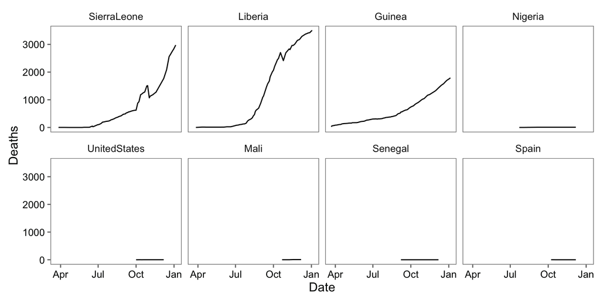

```r
ggplot(ebola, aes(x = Date, y = Deaths)) +
        geom_line() +
        facet_wrap(~ country, ncol = 4) +
        theme_few()
```

Try using the option `scales = "free_y"` in the `facet_wrap()` function (in the `gridExtra` package) and see how that changes these graphs:

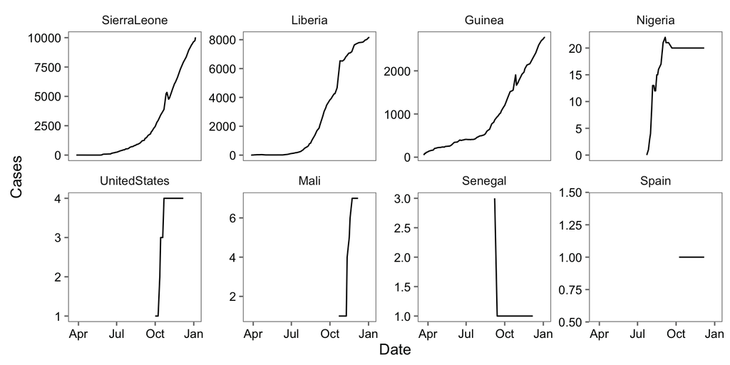

```r
ggplot(ebola, aes(x = Date, y = Cases)) +
        geom_line() +
        facet_wrap(~ country, ncol = 4, scales = "free_y") +
        theme_few()
```

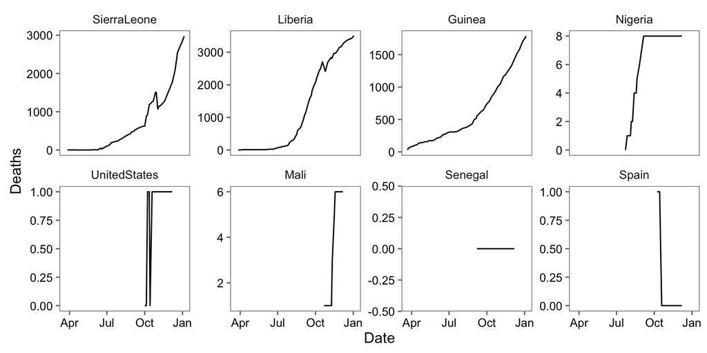

```r
ggplot(ebola, aes(x = Date, y = Deaths)) +
        geom_line() +
        facet_wrap(~ country, ncol = 4, scales = "free_y") +
        theme_few()
```

Put all of the steps of this cleaning process into just a few “chaining” calls. (Note: I’m using `sub` here instead of `strsplit` for the variable-splitting step, just to keep the code a bit cleaner. Again, this is using regular expressions, which we’re cover more later in the course.)

```r
ebola <- read.csv("data/country_timeseries.csv", header = TRUE) %>%
        gather(variable, count, -Date, -Day) %>%
        mutate(type = sub("_.*", "", variable),
               country = sub(".*_", "", variable)) %>%
        select(-Day, -variable) %>%
        mutate(Date = as.Date(Date, format = "%m/%d/%Y")) %>%
        spread(type, count) %>%
        filter(!is.na(Cases) & !is.na(Deaths))

case_sum <- group_by(ebola, country) %>%
        summarize(Cases = sum(Cases, na.rm = TRUE)) %>%
        arrange(desc(Cases))

ebola <- mutate(ebola,
                country = factor(country, levels = case_sum$country))

case_sum
```

```
## Source: local data frame [8 x 2]
##
##        country  Cases
##          (chr)  (int)
## 1  SierraLeone 211169
## 2      Liberia 191351
## 3       Guinea  82099
## 4      Nigeria    636
## 5 UnitedStates     59
## 6         Mali     42
## 7      Senegal     24
## 8        Spain     16
```

```r
head(ebola)
```

```
##         Date country Cases Deaths
## 1 2014-03-22  Guinea    49     29
## 2 2014-03-24  Guinea    86     59
## 3 2014-03-25  Guinea    86     60
## 4 2014-03-26  Guinea    86     62
## 5 2014-03-27  Guinea   103     66
## 6 2014-03-27 Liberia     8      6
```